# COMPSCIX 415.2 Homework 6

Shannon Hamilton

3/11/2018

```r
library(tidyverse)
library(mosaicData)
```

## Exercise 1

*1. What variables are in this data set?*

The variables in this data scet are (1) the survival status of each woman in the data after 20 years, (2) if each woman is a smoker or not, and (3) each woman’s age at the time of the initial survey.

*2. How many observations are there and what does each represent?*

There are 1314 observations in the data. Each represents one woman.

*3. Create a table (use the R code below as a guide) and a visualization of the relationship between smoking status and outcome, ignoring age. What do you see? Does it make sense?*

We see that there are overall more non-smokers than smokers in the data, and more of the non-smokers proportionately were dead at the end of the study than smokers, which is unexpected. I would expect more smokers to be dead, but we are not controlling for age.

```r
data("Whickham")

Whickham %>%
count(smoker , outcome )
```

```
## # A tibble: 4 x 3
##   smoker outcome     n
##   <fct>  <fct>   <int>
## 1 No     Alive     502
## 2 No     Dead      230
## 3 Yes    Alive     443
## 4 Yes    Dead      139
```

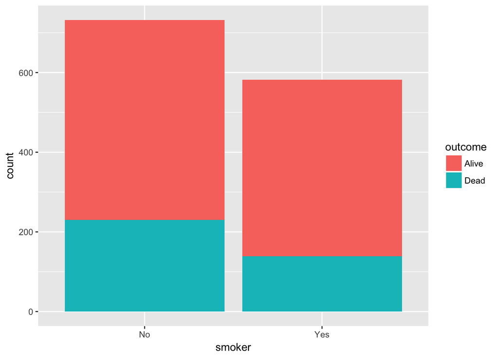

```r
ggplot(Whickham) +
  geom_bar(mapping = aes(x = smoker, fill = outcome))
```

*4. Recode the age variable into an ordered factor with three categories: age <= 44, age > 44 & age <=64, and age > 64. Now, recreate visualization from above, but facet on your new age factor. What do you see? Does it make sense?*

```r
data("Whickham")

Wickham1 <- Whickham %>%
mutate(age2 = cut(age, breaks=c(-Inf, 44, 64, Inf), labels=c("<=44","44_64",">64")))

Wickham1 %>%
count(age2, smoker , outcome )
```

```
## # A tibble: 12 x 4
##    age2  smoker outcome     n
##    <fct> <fct>  <fct>   <int>
##  1 <=44  No     Alive     327
##  2 <=44  No     Dead       12
##  3 <=44  Yes    Alive     270
##  4 <=44  Yes    Dead       15
##  5 44_64 No     Alive     147
##  6 44_64 No     Dead       53
##  7 44_64 Yes    Alive     167
##  8 44_64 Yes    Dead       80
##  9 >64   No     Alive      28
## 10 >64   No     Dead      165
## 11 >64   Yes    Alive       6
## 12 >64   Yes    Dead       44
```

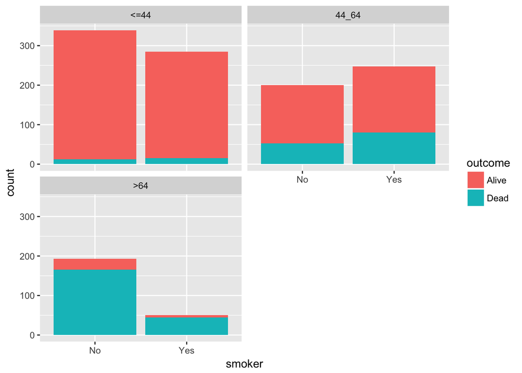

```r
ggplot(Wickham1) +
geom_bar(mapping = aes(x = smoker, fill = outcome)) +
facet_wrap(~ age2, nrow=2)
```

Now the trend aligns to my expectations once I include age as a factor in the analysis.

## Exercise 2

*1. Generate a random sample of size n = 10000 from a gamma(1,2) distribution and plot a histogram or density curve. Use the code below to help you get your sample*

```r
n <- 10000
# look at ?rgamma to read about this function
(gamma_samp <- tibble(x = rgamma(n, shape = 1, scale = 2)))
```

```
## # A tibble: 10,000 x 1
##        x
##    <dbl>
##  1 0.111
##  2 0.953
##  3 0.751
##  4 0.292
##  5 1.54
##  6 2.41
##  7 0.116
##  8 0.905
##  9 0.549
## 10 5.40
## # ... with 9,990 more rows
```

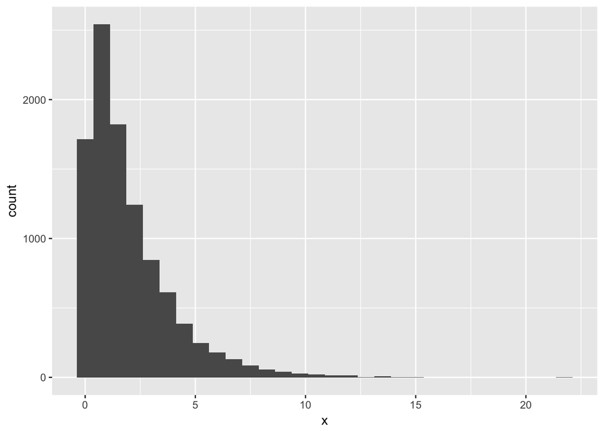

```r
ggplot(gamma_samp, aes(x = x, y = ..count..)) +
geom_histogram()
```

```r
(mean_samp <- mean(gamma_samp$x))
```

```
## [1] 1.986269
```

```r
(sd_samp <- sd(gamma_samp$x))
```

```
## [1] 1.964318
```

The mean and the standard deviation are both close to 2.

*3. Pretend the distribution of our population of data looks like the plot above. Now take a sample of size n = 30 from a Gamma(1,2) distribution, plot the histogram or density curve, and calculate the mean and standard deviation.*

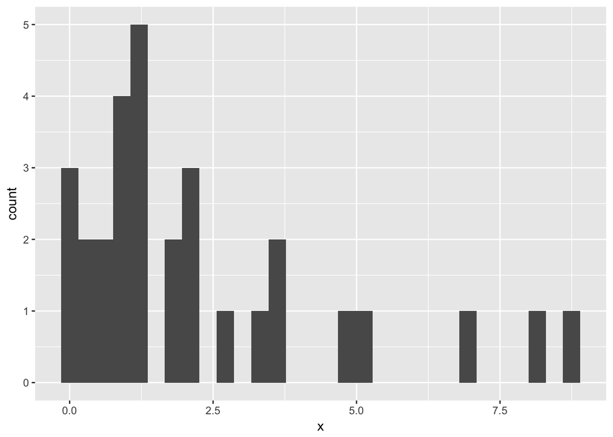

```r
n <- 30
gamma_samp2 <- tibble(x = rgamma(n, shape = 1, scale = 2))


ggplot(gamma_samp2, aes(x = x, y = ..count..)) +
geom_histogram()
```

```r
(mean_samp2 <- mean(gamma_samp2$x))
```

```
## [1] 2.313015
```

```r
(sd_samp2 <- sd(gamma_samp2$x))
```

```
## [1] 2.361301
```

*4. Take a sample of size n = 30, again from the Gamma(1,2) distribution, calculate the mean, and assign it to a vector named mean_samp. Repeat this 10000 times!!!! The code below might help.*

```r
# create a vector with 10000 NAs
mean_samp <- rep(NA, 10000)

# start a loop
for(i in 1:10000) {
g_samp <- rgamma(30, shape = 1, scale = 2)
mean_samp[i] <- mean(g_samp)
}
# Convert vector to a tibble
(mean_samp <- tibble(mean_samp))
```

```
## # A tibble: 10,000 x 1
##    mean_samp
##        <dbl>
##  1      2.21
##  2      2.18
##  3      1.67
##  4      2.65
##  5      2.23
##  6      2.10
##  7      1.34
##  8      2.31
##  9      2.01
## 10      2.05
## # ... with 9,990 more rows
```

*5.Make a histogram of your collection of means from above (mean_samp).*

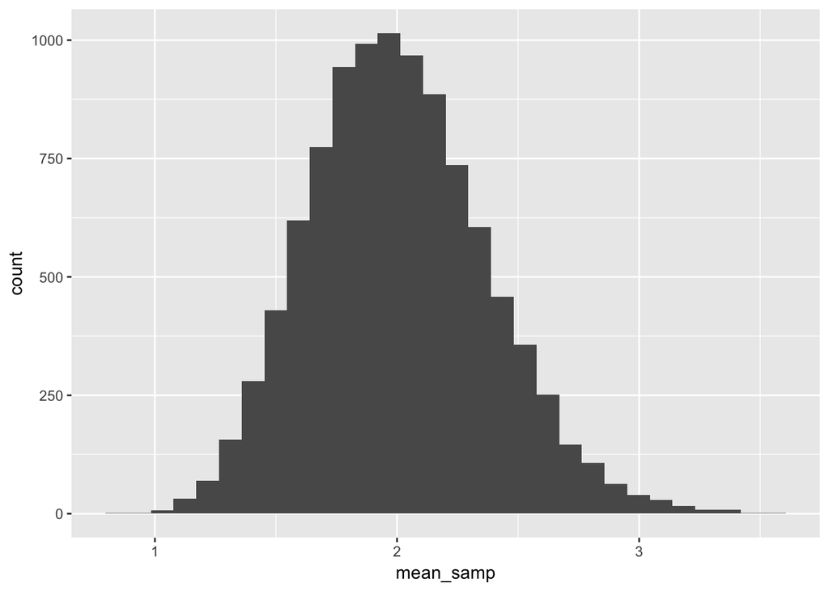

```r
ggplot(mean_samp, aes(x = mean_samp, y = ..count..)) +
geom_histogram()
```

*6. Calculate the mean and standard deviation of all of your sample means.*

```r
(mean_samp3 <- mean(mean_samp$mean_samp))
```

```
## [1] 2.00425
```

```r
(sd_samp3 <- sd(mean_samp$mean_samp))
```

```
## [1] 0.3662937
```

*7. Did anything surprise you about your answers to #6?*

When you look across the means of many samples of a small size (30), then the mean of the means approaches that of what we would expect from the distribution and the same as using one large sample.

*8. According to the Central Limit Theorem, the mean of your sampling distribution should be very close to 2, and the standard deviation of your sampling distribution should be close to σ/√n = 2/√30 = 0.365. Repeat #4-#6, but now with a sample of size n = 300 instead. Do your results match up well with the theorem?*

```r
# create a vector with 10000 NAs
mean_samp <- rep(NA, 10000)

# start a loop
for(i in 1:10000) {
g_samp <- rgamma(300, shape = 1, scale = 2)
mean_samp[i] <- mean(g_samp)
}
# Convert vector to a tibble
(mean_samp <- tibble(mean_samp))
```

```
## # A tibble: 10,000 x 1
##    mean_samp
##        <dbl>
##  1      2.09
##  2      1.97
##  3      2.10
##  4      2.15
##  5      2.04
##  6      1.85
##  7      1.95
##  8      2.06
##  9      2.10
## 10      2.20
## # ... with 9,990 more rows
```

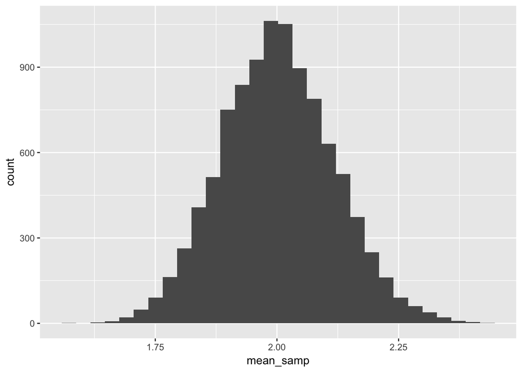

```r
ggplot(mean_samp, aes(x = mean_samp, y = ..count..)) +
geom_histogram()
```

```r
(mean_samp4 <- mean(mean_samp$mean_samp))
```

```
## [1] 2.001759
```

```r
(sd_samp4 <- sd(mean_samp$mean_samp))
```

```
## [1] 0.1155958
```